# Final Project Plot 1

Reane Loiselle

21 May, 2020

# Packages and Data

```r
setwd("C:/Users/loiser066/Downloads/MTH250")
library(tidyverse)
library(patchwork)
source("wind_test.R")
```

```r
df <- read.csv("may_wind&water.csv")
theme_rl <- theme_bw() +
 theme(plot.title=element_text(size=10,face="bold"),
       legend.title=element_text(size=7),
       legend.key.size=unit(1.5,"mm"),
       panel.grid.major=element_line(color="gray70"),
       panel.grid.minor=element_blank(),
       axis.text=element_text(color="royalblue4",size=6),
      panel.background=element_rect(fill="grey90"),)
```

```r
# Wind Plot
pw <- plot.windrose(spd = df$wind_sp,
                    dir = df$wind_dir) +
  theme_rl +
  labs(x=element_blank(),title="May Wind Direction and Velocity",subtitle = "Chequamegon Bay, Lake Superior")
```

```r
# Water Plot
source("water_test.R")
wa <- plot.windrose(spd = df$wa_mag,
                    dir = df$wa_dir) +
  theme_bw() +
 theme(plot.title=element_text(size=10,face="bold"),
       legend.title=element_text(size=7),
       legend.key.size=unit(2,"mm"),
       panel.grid.major=element_line(color="gray70"),
       panel.grid.minor=element_blank(),
       axis.text=element_text(color="royalblue4",size=8),
      panel.background=element_rect(fill="grey90"),) +
labs(x=element_blank(),title ="May Water Direction and Velocity",subtitle = "Chequamegon Bay, Lake Superior",caption="Source: https://waterdata.usgs.gov/usa/nwis/uv?463741090521301")
```

# Wind and Water Roses for May 2019 in the Chequamegon Bay

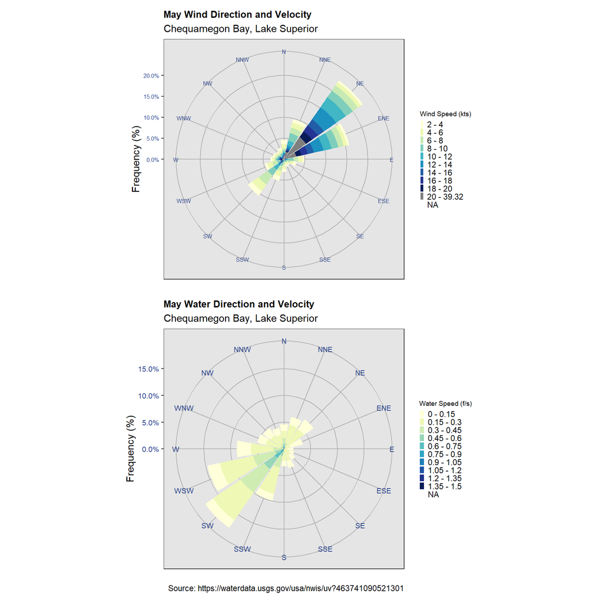

```r
(pw) / (wa)
```

These data are from the United States Geologic Survey (USGS) from their Ashland Breakwater Light Station in the Chequamegon Bay. I used wind and water direction and speed collected every 10 minutes from May 1-31 2019. Water direction and velocity was collected by a side facing Acoustic Doppler Current Profiler (ADCP) facing in a roughly north west direction. In my first analysis I wanted to investigate the relationship between the acollective wind speed and direction for May and the water speed and direction. I observed a very strong correlation between the two, suggesting that wind is likely the main forcing factor for water movement and direction in the Bay. As a note, on these graphs the direct correlation appears to be exactly opposite because wind is recorded as the direction that is it coming from, and water is recorded as the direction it is going in. So in reality they are going the same direction. Choosing to do wind and water rose graphics was an easy decision because it seems to me to be the most logical way of representing wind and water direction. When making my graph I decided to go with a minimal theme as much as possible so as not to take away from the data, but a slight grey to make it less stark. I made the legend smaller so that it wouldn’t take away from the graph, and removed the unnecessary x-axis titles. I also created graph titles to easily distinguish between the wind and water roses, and make the axis labels blue to blend in better. I also gave them unique titles and subtitles for better distinction and description.